# Trabalho 4

Pedro Portela

26 de junho de 2018

## Previsão de recém nascidos com baixo peso

O objetivo desse relatório é prever se um bebê nascerá com peso baixo (menos de 2.5kg). Será utilizada a base de dados disponível em: https://github.com/Efsilvaa/EPSMLRepo/tree/master/Data

#### Visualização inicial

A seguir, ajuste e visualização dos dados.

[output not shown]

```
## 'data.frame':    189 obs. of  11 variables:
##  $ X    : int  85 86 87 88 89 91 92 93 94 95 ...
##  $ low  : Factor w/ 2 levels "0","1": 1 1 1 1 1 1 1 1 1 1 ...
##  $ age  : int  19 33 20 21 18 21 22 17 29 26 ...
##  $ lwt  : int  182 155 105 108 107 124 118 103 123 113 ...
##  $ race : Factor w/ 3 levels "1","2","3": 2 3 1 1 1 3 1 3 1 1 ...
##  $ smoke: Factor w/ 2 levels "0","1": 1 1 2 2 2 1 1 1 2 2 ...
##  $ ptl  : int  0 0 0 0 0 0 0 0 0 0 ...
##  $ ht   : Factor w/ 2 levels "0","1": 1 1 1 1 1 1 1 1 1 1 ...
##  $ ui   : Factor w/ 2 levels "0","1": 2 1 1 2 2 1 1 1 1 1 ...
##  $ ftv  : int  0 3 1 2 0 0 1 1 1 0 ...
##  $ bwt  : int  2523 2551 2557 2594 2600 2622 2637 2637 2663 2665 ...
```

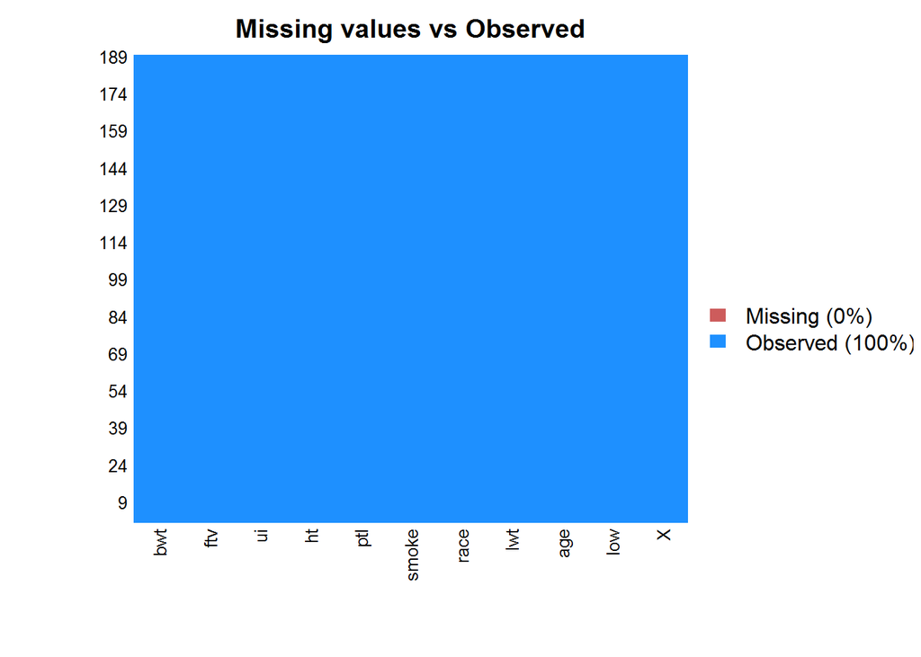

Não havendo observações vazias (NA), não há necessidade de nenhum ajuste nos dados.

A seguir a distribuição de probabilidade do peso no nascimento, com o limite de classificação marcado pela linha vertical.

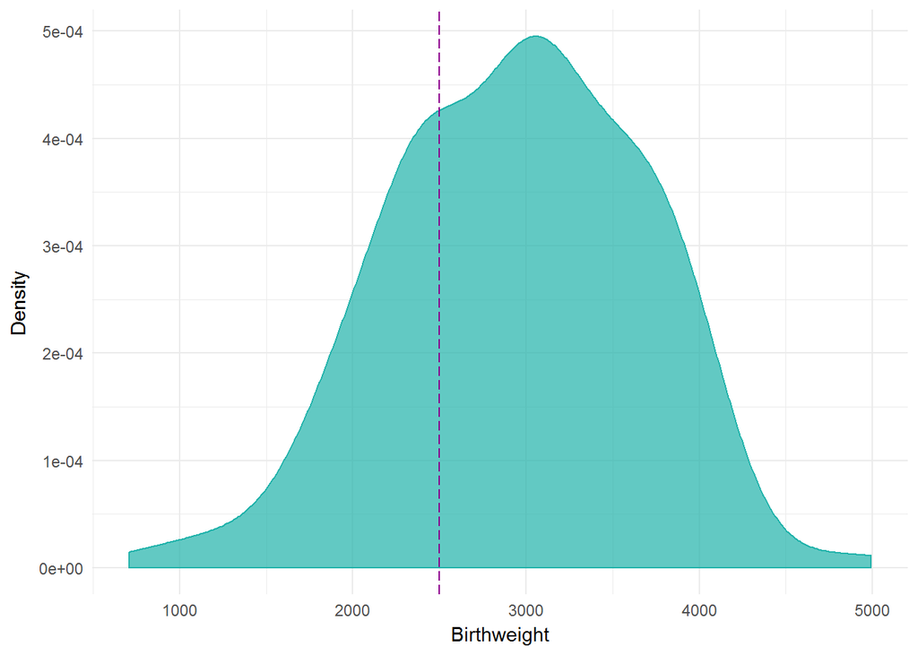

#### Modelo inicial

Inicialmente, faz-se a separação dos dados em treinamento (75%) e teste (25%).

A partir dos dados de treinamento e utilizando a biblioteca *rpart*, constrói-se a árvore de decisão.

```r
fit <- rpart(low ~ age + lwt + race + smoke + ptl + ht + ui + ftv,
               data = train,
               method = "class")

summary(fit)
```

```
## Call:
## rpart(formula = low ~ age + lwt + race + smoke + ptl + ht + ui +
##     ftv, data = train, method = "class")
##   n= 141
##
##           CP nsplit rel error   xerror      xstd
## 1 0.09090909      0 1.0000000 1.000000 0.1250403
## 2 0.04545455      2 0.8181818 1.090909 0.1278792
## 3 0.01136364      3 0.7727273 1.272727 0.1320509
## 4 0.01000000      5 0.7500000 1.318182 0.1327978
##
## Variable importance
## age lwt  ht ptl ftv
##  36  33  19  12   1
##
## Node number 1: 141 observations,    complexity param=0.09090909
##   predicted class=0  expected loss=0.3120567  P(node) =1
##     class counts:    97    44
##    probabilities: 0.688 0.312
##   left son=2 (112 obs) right son=3 (29 obs)
##   Primary splits:
##       lwt   < 106   to the right, improve=4.194180, (0 missing)
##       ptl   < 0.5   to the left,  improve=2.212817, (0 missing)
##       ht    splits as  LR,        improve=1.930480, (0 missing)
##       age   < 27.5  to the right, improve=1.806456, (0 missing)
##       smoke splits as  LR,        improve=1.203244, (0 missing)
##   Surrogate splits:
##       ptl < 1.5   to the left,  agree=0.801, adj=0.034, (0 split)
##
## Node number 2: 112 observations,    complexity param=0.04545455
##   predicted class=0  expected loss=0.25  P(node) =0.7943262
##     class counts:    84    28
##    probabilities: 0.750 0.250
##   left son=4 (102 obs) right son=5 (10 obs)
##   Primary splits:
##       ht    splits as  LR,        improve=2.6901960, (0 missing)
##       age   < 27.5  to the right, improve=2.2021790, (0 missing)
##       ptl   < 0.5   to the left,  improve=1.0204080, (0 missing)
##       race  splits as  LRL,       improve=0.8864469, (0 missing)
##       smoke splits as  LR,        improve=0.8310502, (0 missing)
```

[output cut: 55 more lines]

```
##       ptl   < 0.5   to the left,  improve=1.5920830, (0 missing)
##       lwt   < 111   to the right, improve=0.8171145, (0 missing)
##       age   < 18.5  to the right, improve=0.6354295, (0 missing)
##       smoke splits as  LR,        improve=0.5792607, (0 missing)
##       ui    splits as  LR,        improve=0.5614035, (0 missing)
##
## Node number 18: 67 observations
##   predicted class=0  expected loss=0.238806  P(node) =0.4751773
##     class counts:    51    16
##    probabilities: 0.761 0.239
##
## Node number 19: 9 observations
##   predicted class=1  expected loss=0.4444444  P(node) =0.06382979
##     class counts:     4     5
##    probabilities: 0.444 0.556
```

A árvore de decisão está exposta, juntamente com as variáveis de maior importância, a seguir.

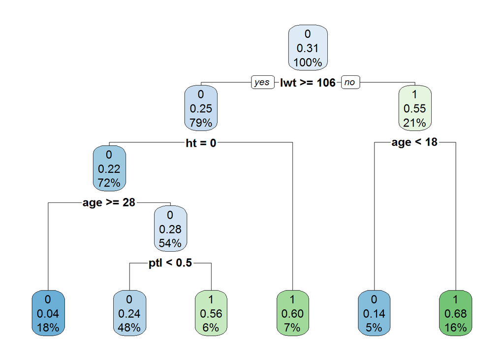

```
##        age        lwt         ht        ptl        ftv
## 5.27707748 4.73221872 2.69019608 1.73671032 0.08430731
```

A nível de curiosidade, tem-se a seguir o gráfico com a relação direta entre a idade da mãe (age) e o peso no nascimento (bwt).

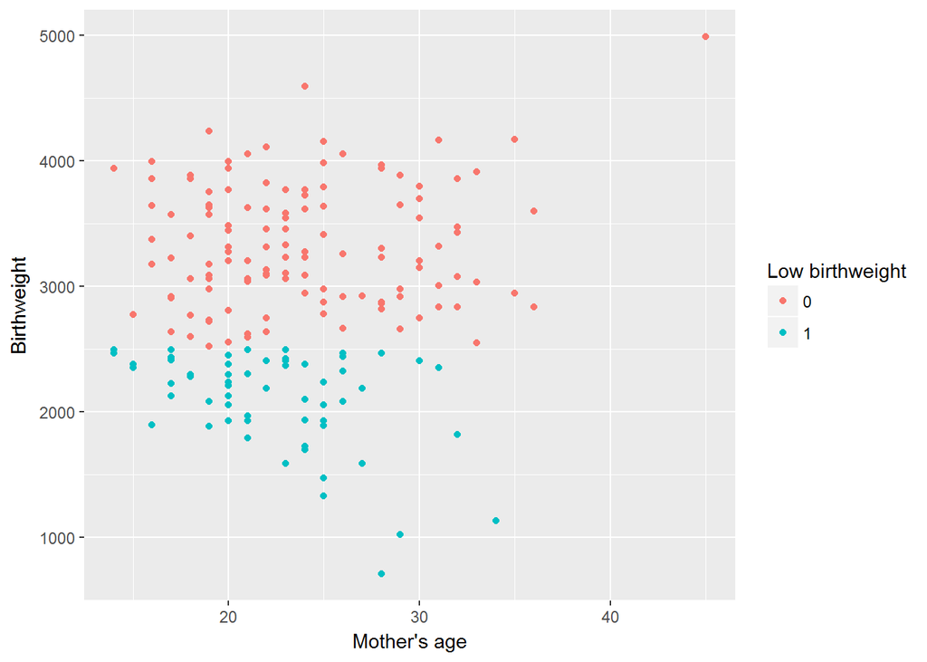

Para testar o modelo, utilizamos os dados separados inicialmente.

```r
prediction <- predict(fit, test, type = "class")
table(prediction, test$low)
```

```
##
## prediction  0  1
##          0 28  9
##          1  5  6
```

```r
result <- prop.table(table(prediction, test$low))
result
```

```
##
## prediction         0         1
##          0 0.5833333 0.1875000
##          1 0.1041667 0.1250000
```

```r
result[1,1] + result[2,2]
```

```
## [1] 0.7083333
```

O modelo atingiu perfomance de ~70,83% de acerto nos dados de teste.

#### Expandindo o modelo

Alterando o parâmetro minsplit, diminuimos o número de observações necessárias em um nó para que o mesmo se divida. Para expandir a árvore, setamos o parâmetro em dois.

```r
fit2 <- rpart(low ~ age + lwt + race + smoke + ptl + ht + ui + ftv,
             data = train,
             method = "class",
             minsplit = 2)
```

A árvore de decisão está exposta a seguir.

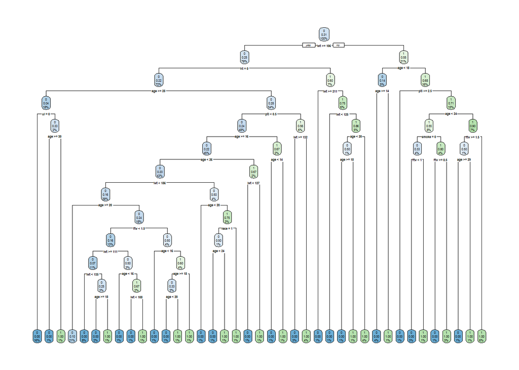

Para testar o modelo, utilizamos os dados separados inicialmente.

[output not shown]

```
##
## prediction2         0         1
##           0 0.5833333 0.1666667
##           1 0.1041667 0.1458333
```

```
## [1] 0.7291667
```

Expandindo a árvore, foi possível aumentar a performance do modelo. Mesmo que pouco, as alterações aumentaram o índice de acertos para ~72.92%.